# Contentious Repertoires

## Contentious Repertoires

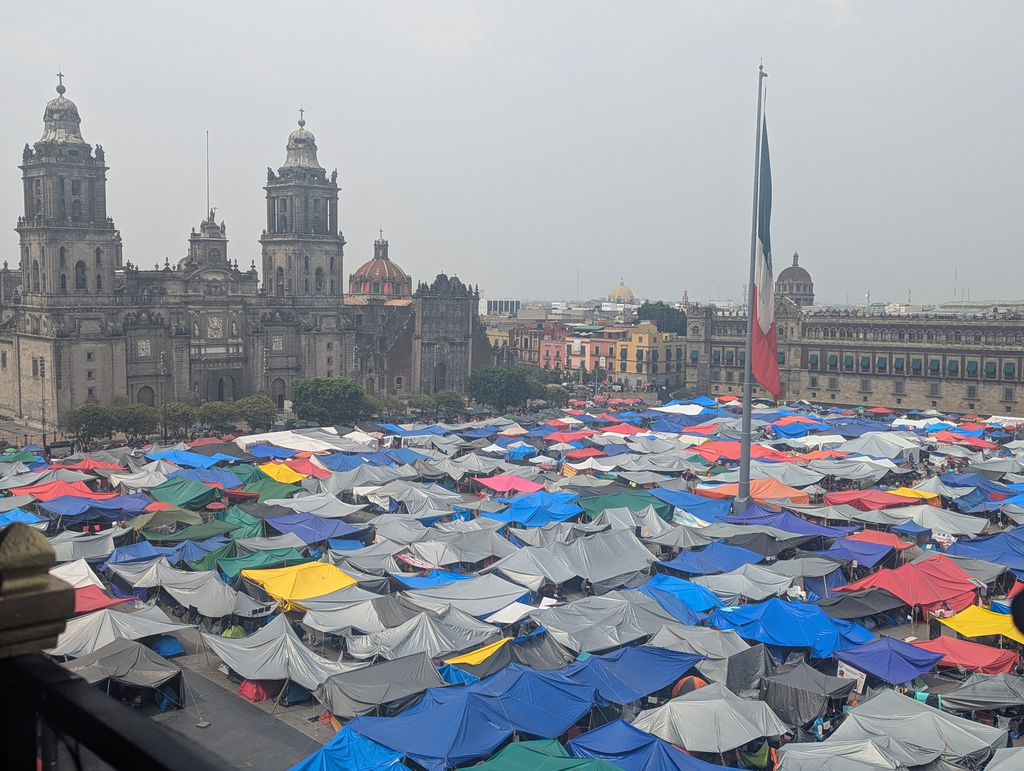

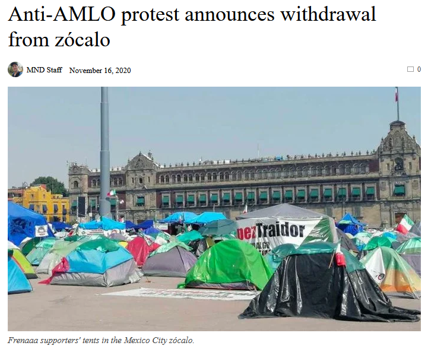

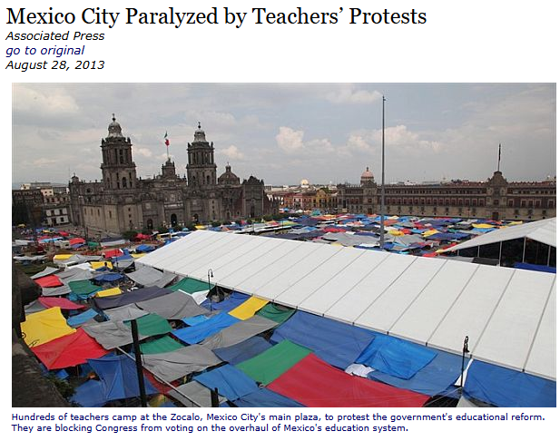

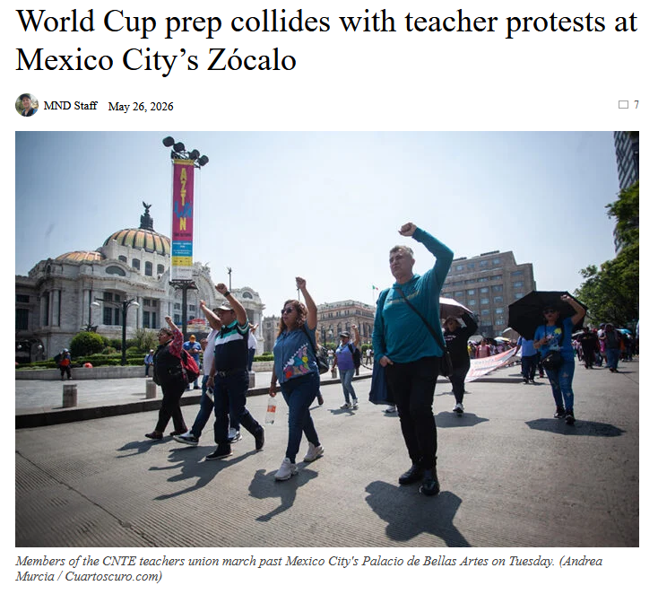

## Contentious Repertoires

- The contentious repertoire is the range of options that are familiar and available for making contentious claims.
- Repertoires change over time and across places. People innovate, some tactics spread, become routine, face repression, etc.
- A lot of research on contentious politics focuses on how and why the repertoire changes.

## Contentious Repertoires

[figure not shown]

Depiction of the mythical Ned Ludd

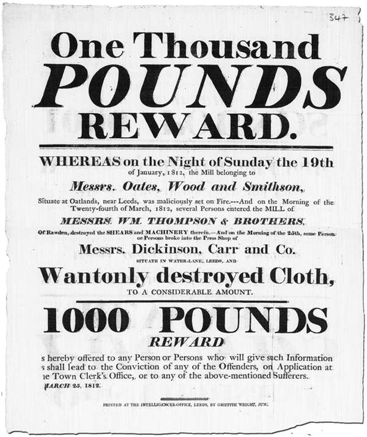

Reward poster seeking capture of some Luddites

Examples

- Food riots and grain seizures
- Invasions and organized poaching
- Destruction of gates, machinery
- Rough music/Chivaree
- Forced illumination
- Mock trials

Features:

- Emulating or co-opting authority: mock trials and effigies
- Appeals to mediating authorities: guilds, churches, village leaders make claims **not** classes or identity groups
- Localized, episodic and direct: if you don’t like the loom, you smash it.
- Parochial: mostly specific to a particular culture.

## The modern repertoire

Much of the “modern” social movement repertoire emerges in Europe during the late 18th and early 19th century.

Examples

- Labor strikes
- Public meetings and petitions
- Marches and demonstrations
- Sustained campaigns organized around a specific set of reforms

Features:

- Targeting national governments and national issues
- “Modular” tactics that could be used for diverse causes
- Autonomous rather than being mediated through local authorities
- More mass-based and decidedly less violent (for both authorities and participants)

## The modern repertoire

[figure not shown]

Declaration of The Stockport Union for the Promotion of Human Happiness

> *On the 16th August I went to Stockport Road about eleven or a little after, and I met a great number of persons advancing toward Manchester with all the regularity of a regiment, only they had no uniform. They were all marching in file, three abreast. They had two banners with them. There were persons by the side, acting as officers and regulating the files. The order was beautiful indeed.* - Francis Phillips (Manchester merchant; 1819)

## The modern repertoire

[figure not shown]

## The modern repertoire

[figure not shown]

## The modern repertoire

- In the present, the tools of the social movement are routine and barely controversial in most democracies.

[figure not shown]

## Social Movements

Three features of modern social movements:

1. A sustained, organized public effort of making collective claims
2. Employment of combinations of the following forms of political action, the creation of associations, public meetings, vigils, rallies, demonstrations, petition drives, statements to and in public media and pamphleteering;
3. Public representations of WUNC: worthiness, unity, numbers, and commitment

## WUNC Displays

> “We are many, we are worthy and unjustly disadvantaged, we agree among ourselves, we are committed, disciplined and legal.” - Tilly 1994
- WUNC displays are a defining feature of social movements
- They operate by generating sympathy/support from other members of the public, rather than through direct actions. Symbolism is central.

## Worthiness

Neat clothing, calm demeanor, emphasis on respectability or social status (mothers, clergy, soldiers)

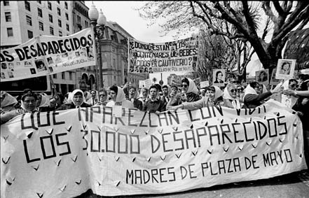

Mothers of the Plaza De Mayo protest in Argentina

## Unity

Uniform clothing or banners, coordinated chants or songs

[figure not shown]

Hong Kong’s Umbrella Movement protest

## Numbers

Large crowd sizes, petitions with lots of signatures, social media activity

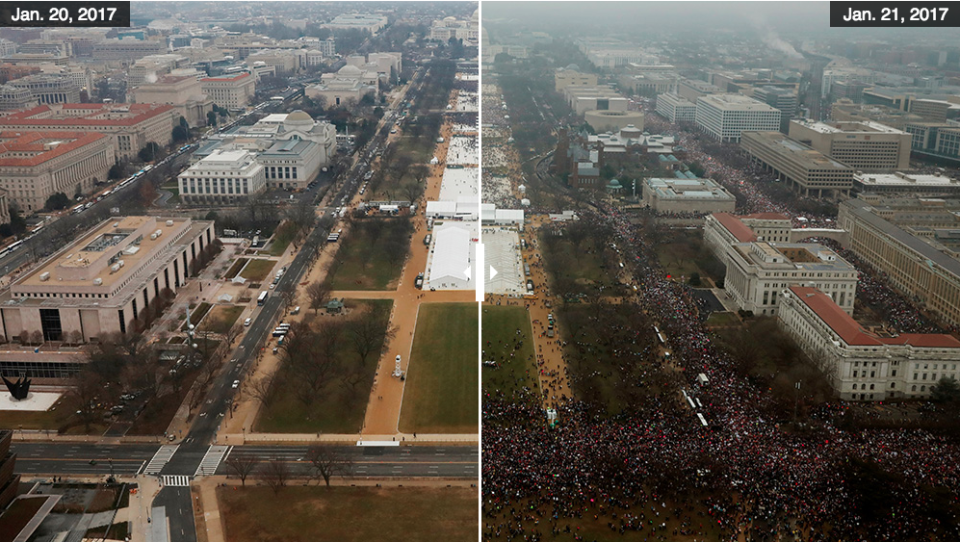

Women’s March (and Trump inauguration crowd)

## Commitment

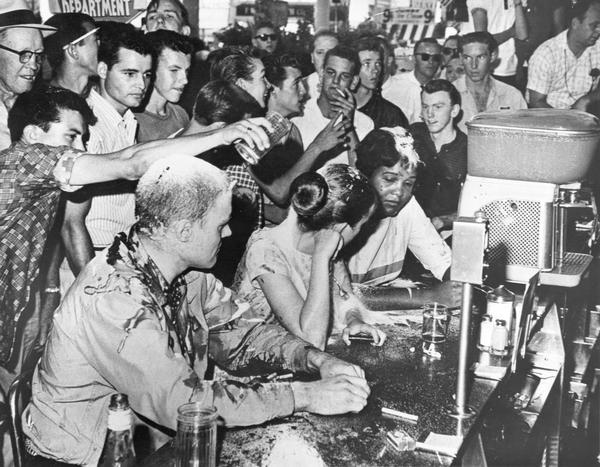

Lunch counter sit in at Woolworth’s in Mississippi

## Diversity(?)

- Wouters (2019) argues that “diversity” claims make up an important and separate aspect of social movement claims.

[figure not shown]

## Research on contentious repertoires

## Effects of WUNC Displays

- Wouters and Walgrave (2017) use a vignette experiment to look at how WUNC(d) displays influenced the views of Belgian politicians towards a fictional asylum seeker movement.

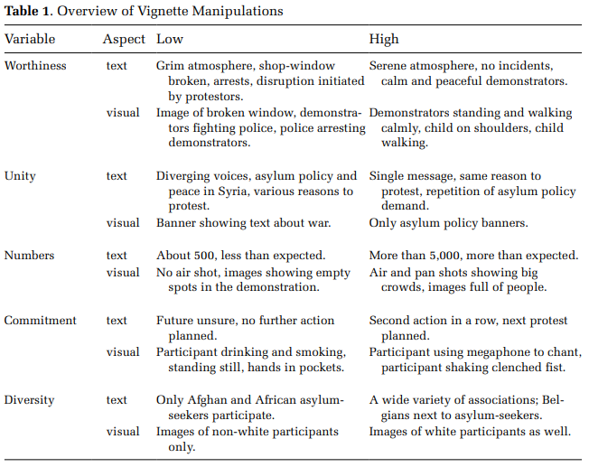

## Effects of WUNC Displays

- Worthiness displays increased the chances politicians would agree with the protests, while numbers and unity increased the perceived salience and the politicians’ willingness to act.
- Committment and diversity, at least in this experiment, didn’t have a statistically signficant effect.

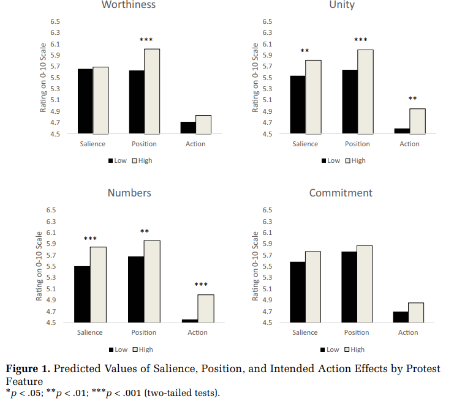

## Tactical Diffusion

Movements constantly create, borrow, and re-use certain tactics, but what factors influence the chances that a new tactic will be taken up by others?

## Diffusion of Shantytowns

- 1985-1990: Students at 46 different universities erected “Shantytowns” to protest South African Apartheid or demand university divestment
- Soule (1997) explored the spread of this tactic in a [research paper.](https://academic.oup.com/sf/article-abstract/75/3/855/2233694)

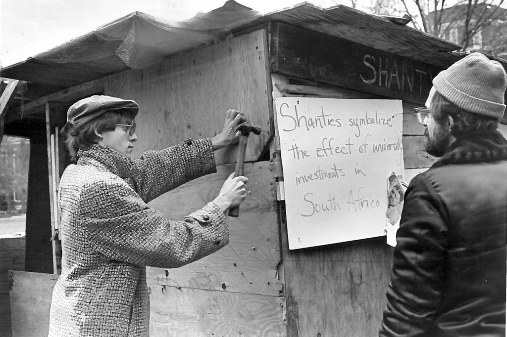

## Diffusion of Shantytowns

Potential routes for diffusion:

- Direct: tactical spread through direct interactions (like a coordinating committee)
- Indirect/Non-relational: spread through indirect linkages of shared identity or culture (if I see people like me doing something, I’ll also do it myself)

## Diffusion of Shantytowns

- *Data:* All four-year, nondenominational, non-specialty, nonprofessional colleges and universities in the US that had some form of investment in South Africa
- *Dependent Variable:* in each year, has college $n$ had a shantytown protest? (ultimately, the outcome to be measured is the probability of having a shantytown protest by time $t$
- *Independent Variable(s):*
  - Characteristics of individual colleges (propensity)
  - Similarities between universities without/without a shantytown at time $t$ (proximity)

Hypothetical data

| University | Time | Has shantytown? | University-specific variables (ex: 1985 enrollment) | “Proximity” (ex: % with same prestige level) |
| --- | --- | --- | --- | --- |
| A | 1985 | No | 35,000 | 1% |
| A | 1986 | No | 35,000 | 10% |
| A | 1987 | Yes | 35,000 | 20% |
| B | 1985 | Yes | 12,000 | 5% |

## Diffusion of Shantytowns

- These data are right-censored (some actors never had a protest) so the author uses a regression model known as an event-history regression, which can account for this condition.

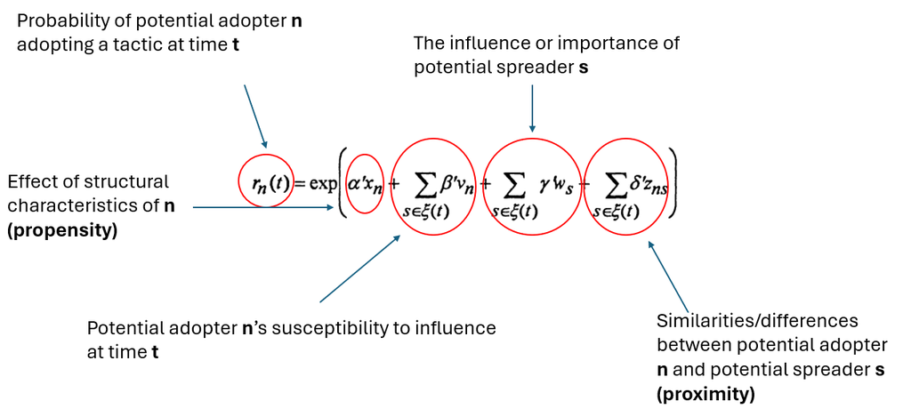

## Diffusion of Shantytowns

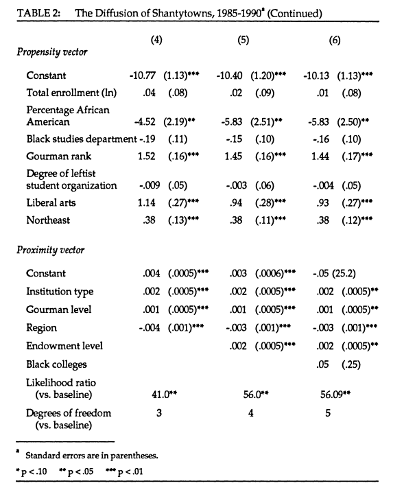

## Tactical Diffusion through collaboration

- Wang and Soule (2012) use Dynamics of Collective Action data to examine the effects of movement collaboration on tactical diffusion.

## Tactical Diffusion through collaboration

- The authors use DOCA to measure patterns of collaboration: if two SMOs appear at the same event, they’re assumed to be collaborating.
- They also use DOCA to get a measure of tactical diffusion: if an SMO picks up a new tactic after a collaboration, they’re assumed to have picked it up from their collaborator.

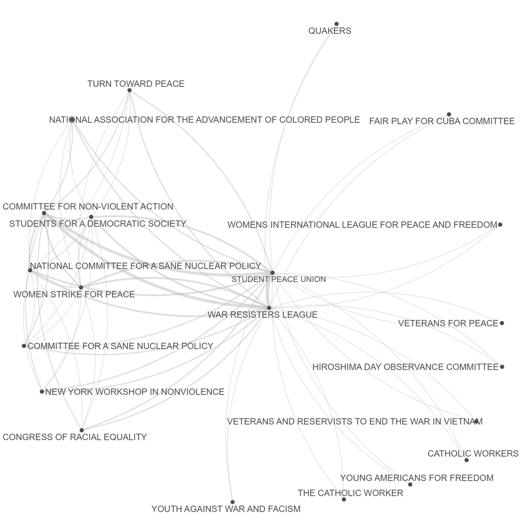

Shared events Student Peace Union Network (1960-1968). Edges reflect organizations appearing together at the same event. Thicker edges indicate that those to organizations appeared together more frequently.

## Tactical Diffusion through collaboration

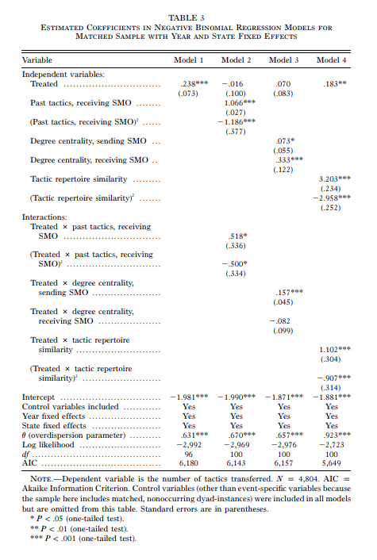

## Next week

- We’ll look at an example of a tactic *leaving* the contentious repertoire, and explore some of the reasons tactics might be abandoned.

## References

Soule, Sarah A. 1997. “The Student Divestment Movement in the United States and Tactical Diffusion: The Shantytown Protest.” *Social Forces* 75 (3): 855–82.

Wang, Dan J, and Sarah A Soule. 2012. “Social Movement Organizational Collaboration: Networks of Learning and the Diffusion of Protest Tactics, 1960–1995.” *American Journal of Sociology* 117 (6): 1674–722.

Wouters, Ruud. 2019. “The Persuasive Power of Protest. How Protest Wins Public Support.” *Social Forces* 98 (1): 403–26.

Wouters, Ruud, and Stefaan Walgrave. 2017. “Demonstrating Power: How Protest Persuades Political Representatives.” *American Sociological Review* 82 (2): 361–83.